# Homework 7

Arden Moser

2026-01-27

## Instructions

Answer the following questions and/or complete the exercises in RMarkdown. Please embed all of your code and push the final work to your repository. Your report should be organized, clean, and run free from errors. Remember, you must remove the `#` for any included code chunks to run.

## Load the tidyverse

```r
library("tidyverse")
library("janitor")
```

## Data

For this assignment, we will use data from a study on elephants and the effects of poaching on tusk size.

Reference: [Chiyo, Patrick I., Vincent Obanda, and David K. Korir. “Illegal tusk harvest and the decline of tusk size in the African elephant.” Ecology and Evolution 5, 22: 5216–5229 (2015)](https://doi.org/10.1002/ece3.1769). Data deposited at [Dryad Digital Repository](https://doi.org/10.5061/dryad.h6t7j).

**1. Before starting data analysis, read the abstract of the paper to get an idea of the questions being asked. In 2-3 sentences, describe what the study is testing and the variables involved.**

This study is testing if severe historical elephant harvests have caused future generations of elephants having smaller tasks. The variable involved were year of smaple collection, sex of the elephant, estimated age of elephant, shoulder height in cm, tusk length in cm, and tusk circumference in cm.

**2. Load `elephants.csv` and store it as a new object called `elephants`.**

```r
elephants <- read_csv("data/elephants.csv")
```

**3. Clean the data by converting variable names to lowercase with no spaces or special characters.**

```r
elephants %>% clean_names()
```

```
## # A tibble: 777 × 7
##    years_of_sample_collection elephant_id sex   estimated_age_years
##    <chr>                      <chr>       <chr>               <dbl>
##  1 1966-68                    12          f                   0.08
##  2 1966-68                    34          f                   0.08
##  3 1966-68                    162         f                   0.083
##  4 1966-68                    292         f                   0.083
##  5 1966-68                    11          f                   0.25
##  6 1966-68                    152         f                   0.25
##  7 1966-68                    264         f                   0.25
##  8 1966-68                    263         f                   0.5
##  9 1966-68                    266         f                   0.5
## 10 1966-68                    217         f                   1
## # ℹ 767 more rows
## # ℹ 3 more variables: shoulder_height_in_cm <dbl>, tusk_length_in_cm <dbl>,
## #   tusk_circumference_in_cm <dbl>
```

**4. Use one or more of the summary functions you have learned to get an idea of the structure of the data.**

```r
glimpse(elephants)
```

```
## Rows: 777
## Columns: 7
## $ `Years of sample collection` <chr> "1966-68", "1966-68", "1966-68", "1966-68…
## $ `Elephant ID`                <chr> "12", "34", "162", "292", "11", "152", "2…
## $ Sex                          <chr> "f", "f", "f", "f", "f", "f", "f", "f", "…
## $ `Estimated Age (years)`      <dbl> 0.080, 0.080, 0.083, 0.083, 0.250, 0.250,…
## $ `shoulder Height in  cm`     <dbl> 102, 89, 89, 92, 133, 100, 93, 108, 108, …
## $ `Tusk Length in cm`          <dbl> NA, NA, NA, NA, NA, NA, NA, NA, NA, NA, N…
## $ `Tusk Circumference   in cm` <dbl> NA, NA, NA, NA, NA, NA, NA, NA, NA, NA, N…
```

**5. Use `mutate()` Change the variables `years_of_sample_collection`, `elephant_id`, and `sex` to factors. Be sure to store the output as a new dataframe and use it for the remaining questions.**

```r
elephants_factors <- elephants %>% clean_names() %>%
  mutate(across(c(years_of_sample_collection, elephant_id, sex), as.factor))
elephants_factors
```

```
## # A tibble: 777 × 7
##    years_of_sample_collection elephant_id sex   estimated_age_years
##    <fct>                      <fct>       <fct>               <dbl>
##  1 1966-68                    12          f                   0.08
##  2 1966-68                    34          f                   0.08
##  3 1966-68                    162         f                   0.083
##  4 1966-68                    292         f                   0.083
##  5 1966-68                    11          f                   0.25
##  6 1966-68                    152         f                   0.25
##  7 1966-68                    264         f                   0.25
##  8 1966-68                    263         f                   0.5
##  9 1966-68                    266         f                   0.5
## 10 1966-68                    217         f                   1
## # ℹ 767 more rows
## # ℹ 3 more variables: shoulder_height_in_cm <dbl>, tusk_length_in_cm <dbl>,
## #   tusk_circumference_in_cm <dbl>
```

**6. From which years were data collected? Show the sample periods below.**

```r
elephants_factors %>%
  select(years_of_sample_collection) %>%
  distinct()
```

```
## # A tibble: 2 × 1
##   years_of_sample_collection
##   <fct>
## 1 1966-68
## 2 2005-13
```

The sample periods were from 1966 to 1968 and from 2005 to 2013.

**7. How many males and females were sampled in this study?**

```r
elephants_factors %>%
  count(sex)
```

```
## # A tibble: 2 × 2
##   sex       n
##   <fct> <int>
## 1 f       416
## 2 m       361
```

416 females and 361 males were sampled in this study.

**8. What is the mean, median, and standard deviation for age of males and females included in the study? Separate the results by year of sample collection. Does the sampling look even between years and sexes?**

```r
elephants_factors %>%
  select(years_of_sample_collection, sex, estimated_age_years) %>%
  group_by(years_of_sample_collection, sex) %>%
  summarise(mean_age = mean(estimated_age_years,na.rm = TRUE),
            median_age = median(estimated_age_years,na.rm = TRUE),
            sd_age = sd(estimated_age_years,na.rm = TRUE),
            sample_size = n(),
            .groups = "drop"
            )
```

```
## # A tibble: 4 × 6
##   years_of_sample_collection sex   mean_age median_age sd_age sample_size
##   <fct>                      <fct>    <dbl>      <dbl>  <dbl>       <int>
## 1 1966-68                    f         17.6       15    13.6          323
## 2 1966-68                    m         10.8        8     9.19         282
## 3 2005-13                    f         17.9       17.5  11.0           93
## 4 2005-13                    m         16.7        9    13.9           79
```

**9. Is age (independent variable) a positive predictor of tusk length (dependent variable)? Create a plot that shows the relationship between these variables and add a linear model fit line.**

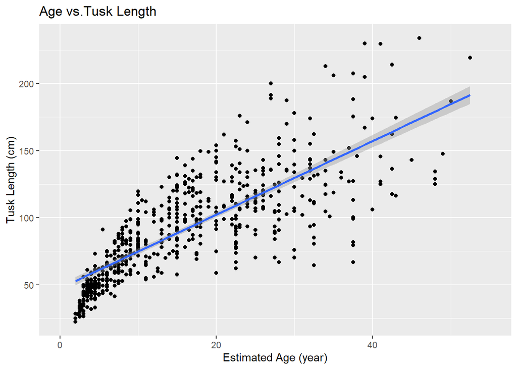

```r
elephants_factors %>%
  select(estimated_age_years, tusk_length_in_cm) %>%
  ggplot(aes(x = estimated_age_years, y = tusk_length_in_cm)) +
  geom_point() +
  geom_smooth(na.rm = TRUE, method = "lm") +
  labs(
    title = "Age vs.Tusk Length",
    x = "Estimated Age (year)",
    y = "Tusk Length (cm)"
  )
```

Age is indeed a positive predictor of tusk length due to the above plot producing a positive, linear trend line.

**10. Is shoulder height (independent variable) a positive predictor of tusk length (dependent variable)? Create a plot that shows the relationship between these variables and add a linear model fit line.**

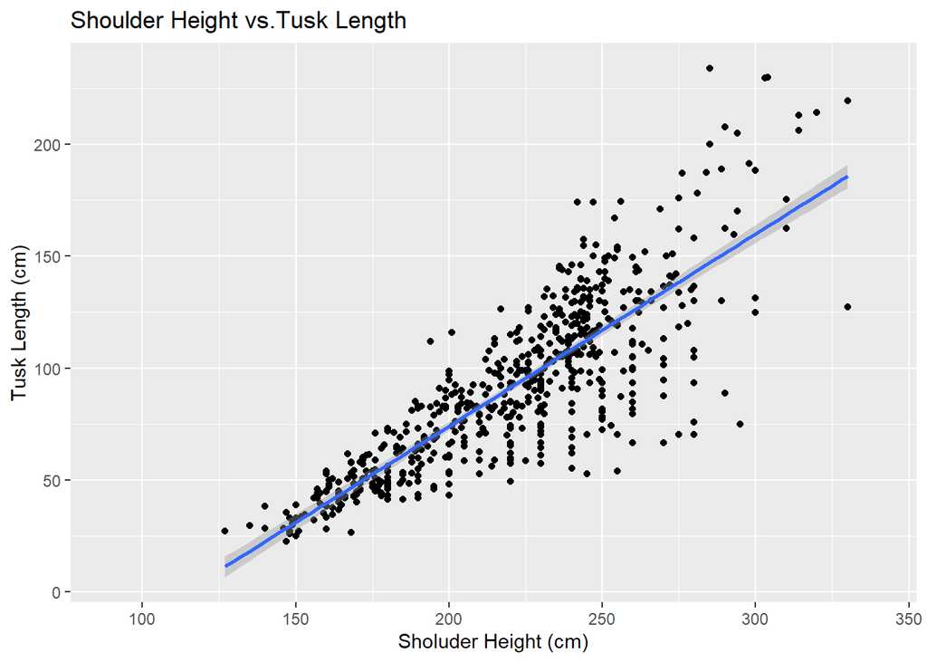

```r
elephants_factors %>%
  select(shoulder_height_in_cm, tusk_length_in_cm) %>%
  ggplot(aes(x = shoulder_height_in_cm, y = tusk_length_in_cm)) +
  geom_point() +
  geom_smooth(na.rm = TRUE, method = "lm") +
  labs(
    title = "Shoulder Height vs.Tusk Length",
    x = "Sholuder Height (cm)",
    y = "Tusk Length (cm)"
  )
```

Shoulder is indeed a positive predictor of tusk length due to the above plot producing a positive, linear trend line.

**11. The authors argue that because poachers preferentially target elephants with large tusks, this has resulted in a decrease in average tusk length. Is this supported by the data? Show your code and calculations below.**

```r
elephants_factors %>%
  select(years_of_sample_collection, tusk_length_in_cm) %>%
  group_by(years_of_sample_collection) %>%
  summarise(mean_tusk_length = mean(tusk_length_in_cm, na.rm = TRUE))
```

```
## # A tibble: 2 × 2
##   years_of_sample_collection mean_tusk_length
##   <fct>                                 <dbl>
## 1 1966-68                                96.9
## 2 2005-13                                77.2
```

This argument has support as the observed average tusk length from 2005 to 2013 is about 19 cm lower than the observed average tusk length from 1966 to 1968.

**12. Male elephants reach effective sexual maturity at 25 years while females are sexually mature at 12 years. Make a new dataframe that extracts only the males and females at sexual maturity. Then, make a plot that shows the range of tusk length between the two sample periods for these mature elephants.**

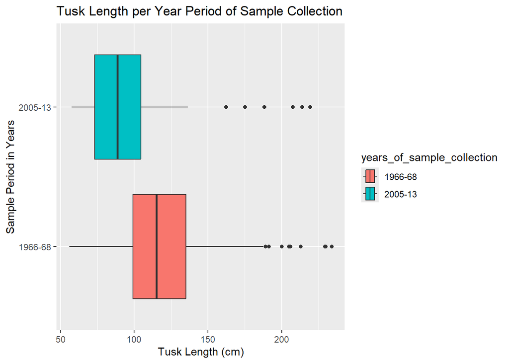

```r
elephants_sexually_mature <- elephants_factors %>%
  filter(sex == "m" & estimated_age_years >= 25 | sex == "f" & estimated_age_years >= 12)
elephants_sexually_mature %>%
  select(years_of_sample_collection, tusk_length_in_cm) %>%
  ggplot(aes(x = tusk_length_in_cm, y = years_of_sample_collection, fill = years_of_sample_collection)) +
  geom_boxplot(na.rm=TRUE) +
  labs(
    title = "Tusk Length per Year Period of Sample Collection",
    x = "Tusk Length (cm)",
    y = "Sample Period in Years"
  )
```

## Submit the Homework

1. Save your work and knit the .rmd file.
2. Open the .html file and “print” it to a .pdf file in Google Chrome (not Safari).
3. Go to the class Canvas page and open Gradescope.
4. Submit your .pdf file to the homework assignment- be sure to assign the pages to the correct questions.
5. Commit and push your work to your repository.